# Tarea 3

José Manuel Proudinat - 130056

```r
# Paquetes
library(dplyr)
library(bnlearn)
library(Rgraphviz)
```

```r
# Leemos los datos
setwd("/Users/Josman/Projects/Multivariate-statistics/tareas/t3-modelos-locales")
admisiones <- read.table('admisiones', head=T, row.names=1, sep=',')
```

# Modelo 1

Haremos un modelo primero para la relación Género -> Admisión. Y observaremos resultados basándonos en datos. Primero tomamos los datos necesarios para este análisis, y generamos la red bayesiana inferida de ellos.

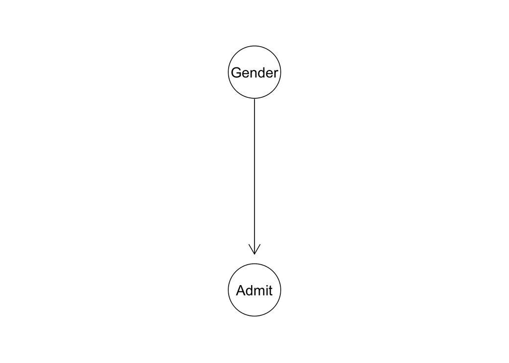

```r
data.mod1 <- admisiones %>% select(Gender, Admit)

# Aprendemos la estructura de la red bayesiana
net.mod1 <- hc(data.mod1, score='aic')
# Hacemos el ajuste
fit.net.mod1 <- bn.fit(net.mod1, data=data.mod1, method='mle')
graphviz.plot(net.mod1)
```

Ahora veamos cómo se ven las probabilidades de admisión dado el género de la persona.

```r
fit.net.mod1[['Admit']]
```

```
##
##   Parameters of node Admit (multinomial distribution)
##
## Conditional probability table:
##
##           Gender
## Admit         Female      Male
##   Admitted 0.3035422 0.4451877
##   Rejected 0.6964578 0.5548123
```

Podemos notar que, dados los datos, existe una diferencia entre la probabilidad de admisión entre hombres y mujeres. Los hombres muestran una mayor probabilidad de ser admitidos.

# Modelo 2

Ahora queremos analizar el modelo Género -> Departamento -> Admisión. Haremos el proceso similar al que hicimos con el modelo anterior.

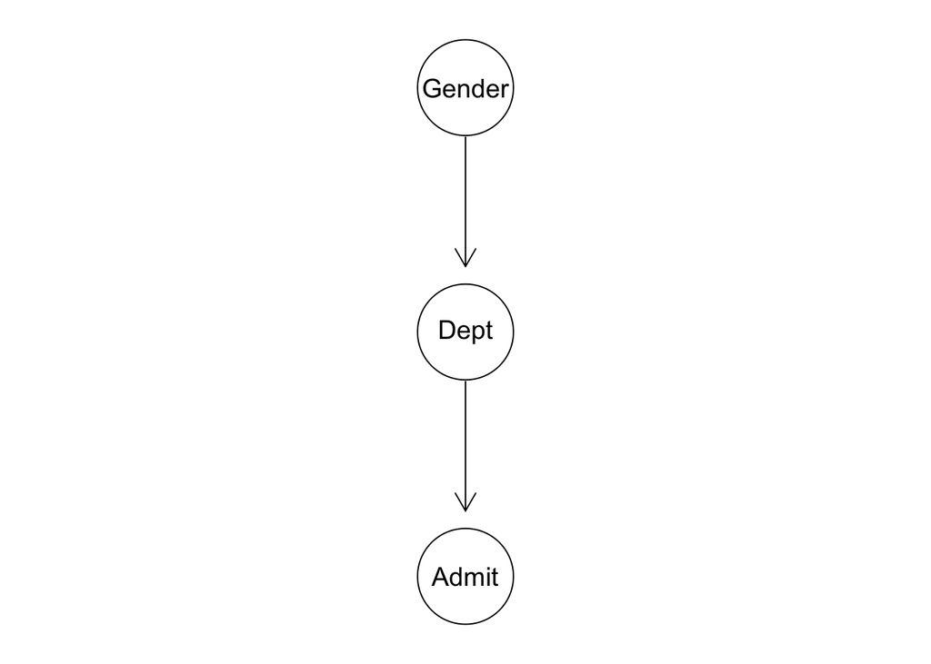

```r
data.mod2 <- admisiones %>% select(Gender, Dept, Admit)

# Aprendemos la estructura de la red bayesiana
black <- data.frame(from = c('Gender'), to = c('Admit'))
net.mod2 <- hc(data.mod2, score='aic', blacklist=black)
# Hacemos el ajuste
fit.net.mod2 <- bn.fit(net.mod2, data=data.mod2, method='mle')
graphviz.plot(net.mod2)
```

Vemos las probabilidades de ser admitido:

```r
fit.net.mod2
```

```
##
##   Bayesian network parameters
##
##   Parameters of node Gender (multinomial distribution)
##
## Conditional probability table:
##
##    Female      Male
## 0.4054353 0.5945647
##
##   Parameters of node Dept (multinomial distribution)
##
## Conditional probability table:
##
##     Gender
## Dept     Female       Male
##    A 0.05885559 0.30657748
##    B 0.01362398 0.20810108
##    C 0.32316076 0.12077295
##    D 0.20435967 0.15496098
##    E 0.21416894 0.07097733
##    F 0.18583106 0.13861018
##
##   Parameters of node Admit (multinomial distribution)
##
## Conditional probability table:
##
##           Dept
## Admit               A          B          C          D          E
##   Admitted 0.64415863 0.63247863 0.35076253 0.33964646 0.25171233
##   Rejected 0.35584137 0.36752137 0.64923747 0.66035354 0.74828767
##           Dept
## Admit               F
##   Admitted 0.06442577
##   Rejected 0.93557423
```

Observando las tablas de probabilidad, notamos que las mujeres hacen más aplicaciones a los departamentos C, D, E y F que, sin importar el género, tienen menos probabilidad de admisión que los otros. Al contrario, los hombres hacen aplicaciones a departamentos con mayor tasa de admisión. Con esto podemos pensar que no necesariamente existe discriminación por género, sino que las aplicaciones se distribuyen de maner distinta y esto es o que genera ese cambio en la tasa de admisión.

Por esta razón es que es posible no indicar una flecha directa de Género a Admisón pues notamos que la relación se da por el departamento.